# part_2

```
checkpoint: OpenAI CLIP ViT-B/32
logit_scale (learned): 100.00000762939453
Compose(
    Resize(size=224, interpolation=bicubic, max_size=None, antialias=warn)
    CenterCrop(size=(224, 224))
    <function _convert_image_to_rgb at 0x7876225b9b80>
    ToTensor()
    Normalize(mean=(0.48145466, 0.4578275, 0.40821073), std=(0.26862954, 0.26130258, 0.27577711))
)
```

```
20 images
```

```
cosine range: 0.1186 to 0.3608
logit range:  11.86 to 36.08
```

```
max abs difference between my logits and model output: 0.000011
argmax agreement: True
```

```
zero-shot accuracy: 1.000
[OK ] english_springer   -> English springer
[OK ] english_springer   -> English springer
[OK ] english_springer   -> English springer
[OK ] english_springer   -> English springer
[OK ] chain_saw          -> chain saw
[OK ] chain_saw          -> chain saw
[OK ] chain_saw          -> chain saw
[OK ] chain_saw          -> chain saw
[OK ] church             -> church
[OK ] church             -> church
[OK ] church             -> church
[OK ] church             -> church
[OK ] garbage_truck      -> garbage truck
[OK ] garbage_truck      -> garbage truck
[OK ] garbage_truck      -> garbage truck
[OK ] garbage_truck      -> garbage truck
[OK ] golf_ball          -> golf ball
[OK ] golf_ball          -> golf ball
[OK ] golf_ball          -> golf ball
[OK ] golf_ball          -> golf ball
```

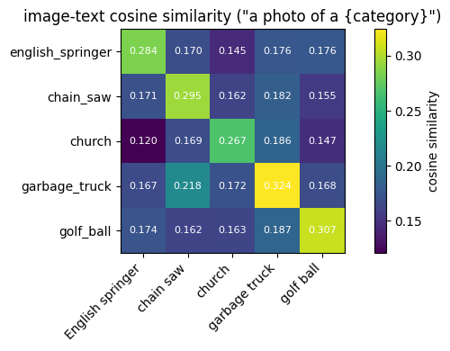

```
{}                           accuracy 1.000   mean confidence 0.994
a photo of a {}              accuracy 1.000   mean confidence 0.998
an image showing a {}        accuracy 1.000   mean confidence 0.994
```

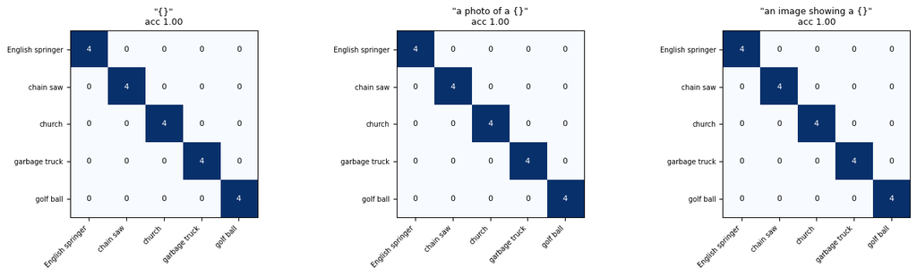

```
image                              bare   a photo of    delta
chain_saw/0004034.JPEG           0.9160       0.9684  +0.0524
church/0005598.JPEG              0.9863       0.9992  +0.0129
english_springer/0002294.JPEG    0.9944       0.9999  +0.0054
chain_saw/0006043.JPEG           0.9964       0.9977  +0.0013
church/0004939.JPEG              0.9988       0.9997  +0.0008
```

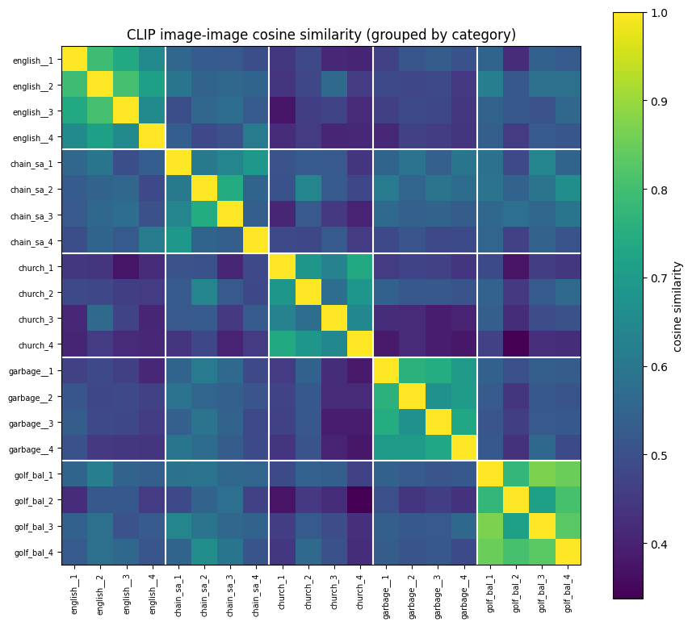

```
mean within-category similarity:  0.7087
mean across-category similarity:  0.5011

English springer   within-category mean 0.7268
chain saw          within-category mean 0.6281
church             within-category mean 0.6612
garbage truck      within-category mean 0.7194
golf ball          within-category mean 0.8082
```

```
most similar pairs:
  0.8706 [same] golf_ball/0002314.JPEG  <->  golf_ball/0006468.JPEG
  0.8509 [same] golf_ball/0002314.JPEG  <->  golf_ball/0007755.JPEG
  0.8314 [same] golf_ball/0006468.JPEG  <->  golf_ball/0007755.JPEG
  0.8067 [same] golf_ball/0003793.JPEG  <->  golf_ball/0007755.JPEG
  0.8040 [same] english_springer/0001968.JPEG  <->  english_springer/0002294.JPEG

highest cross-category pairs:
  0.6646 chain_saw/0004034.JPEG  <->  golf_ball/0007755.JPEG
  0.6396 chain_saw/0004034.JPEG  <->  church/0005295.JPEG
  0.6378 chain_saw/0000537.JPEG  <->  golf_ball/0006468.JPEG
  0.6197 english_springer/0001968.JPEG  <->  golf_ball/0002314.JPEG
  0.6128 chain_saw/0004034.JPEG  <->  garbage_truck/0001144.JPEG

lowest within-category pairs:
  0.5390 chain_saw/0005506.JPEG  <->  chain_saw/0006043.JPEG
  0.5502 chain_saw/0004034.JPEG  <->  chain_saw/0006043.JPEG
  0.5775 church/0005295.JPEG  <->  church/0005598.JPEG
  0.6046 chain_saw/0000537.JPEG  <->  chain_saw/0004034.JPEG
  0.6319 church/0004939.JPEG  <->  church/0005598.JPEG
```

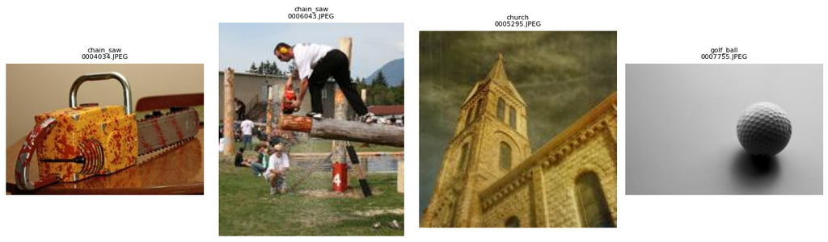

# Project 1, Part 2: CLIP for Image–Text Matching and Zero-Shot Classification

Checkpoint: OpenAI CLIP `ViT-B/32`, loaded via the `clip` package. Device: CPU. Image collection: the same 20 images used in Part 1. Learned logit scale: 100.0 (`model.logit_scale.exp()`).

## Task 1: Implementing the similarity calculation

The computation was implemented directly rather than taken from the model's forward pass:

1. **L2 normalization.** Image and text embeddings are each divided by their own L2 norm, placing every embedding on the unit hypersphere. After this step the dot product between any image and text embedding equals their cosine similarity.
2. **Cosine similarity matrix.** The normalized image matrix (20 x 512) is multiplied by the transposed normalized text matrix (512 x 5), giving a 20 x 5 matrix of cosine similarities.
3. **Scaling to logits.** Each similarity is multiplied by the checkpoint's learned scalar `logit_scale.exp()` = 100.0. This parameter is trained jointly with the encoders.
4. **Softmax and prediction.** Softmax is applied across the 5 candidate texts for each image, and the highest-probability text is the prediction.

### Verification against the built-in output

Maximum absolute difference between the hand-computed logits and `model(images, texts)`: **0.000011**. Argmax agreement: **all 20 images**. The residual difference is float32 rounding, confirming the implementation matches the library's internal computation.

### Cosine similarity, logits, and probabilities

These are three stages of the same quantity and are not interchangeable.

**Softmax probabilities** are the logits normalized to sum to 1 across the candidate texts.

### Why probabilities depend on the candidate set

Softmax normalizes over whichever texts are supplied. The numerator for a given text depends only on that text, but the denominator is the sum over all candidates, so adding, removing, or changing any candidate changes every probability in the row.

This means a CLIP "confidence" is not a property of the image–text pair alone. An image of a church scored against `["church", "golf ball"]` will show near-1.0 confidence for church; the same image scored against `["church", "monastery", "cathedral", "chapel"]` will divide its mass across four plausible options and report much lower confidence for each. The underlying cosine similarities are unchanged in both cases.

This is the central difference from Part 1. ViT's 1000-way softmax is fixed at training time. CLIP's candidate set is chosen at inference time, which makes the task definition itself a parameter of the experiment.

## Task 2: Prompt wording

| Template | Accuracy | Mean confidence |
| --- | --- | --- |
| `{category}` | 1.000 | 0.994 |
| `a photo of a {category}` | 1.000 | 0.998 |
| `an image showing a {category}` | 1.000 | 0.994 |

All three templates classify all 20 images correctly, so the three confusion matrices are identical and purely diagonal. The templates differ only in confidence.

### Where wording changed the score

Comparing the bare category name against `a photo of a {category}`:

| Image | bare | "a photo of a" | change |
| --- | --- | --- | --- |
| chain_saw/...4034 | 0.9160 | 0.9684 | +0.0524 |
| church/...5598 | 0.9863 | 0.9992 | +0.0129 |
| english_springer/...2294 | 0.9944 | 0.9999 | +0.0054 |
| chain_saw/...6043 | 0.9964 | 0.9977 | +0.0013 |
| church/...4939 | 0.9988 | 0.9997 | +0.0008 |

The images where the template helped most are the ones that were hardest for both models. `chain_saw/...4034` is the image ViT classified as *mousetrap*; `church/...5598` is the one ViT classified as *alp*; `church/...4939` is the one ViT classified as *monastery*. On images both models find easy, the template makes essentially no difference, since confidence is already above 0.999 and cannot move. The benefit of prompt engineering is concentrated on ambiguous inputs.

A plausible explanation is distribution matching: CLIP's training captions are natural sentences, not isolated nouns, so `a photo of a chain saw` lies closer to the text distribution the encoder was trained on than the bare token sequence `chain saw`. This remains a hypothesis — with 20 images and no failure cases, these data cannot establish it.

### Why prompting is not fine-tuning

The model weights are identical across all three templates. Nothing is updated: no forward/backward pass over training data, no gradients, no optimizer step. Changing the prompt changes only the **text embeddings being compared against**, which moves the decision boundaries in the existing embedding space without moving any point in that space.

Fine-tuning would alter the encoders themselves, changing where every image and every text lands. Prompting rearranges the reference points; fine-tuning rearranges the space.

### Comparison with Part 1

|  | Top-1 accuracy |
| --- | --- |
| ViT-B/16 (Part 1) | 0.750 |
| CLIP ViT-B/32 zero-shot (Part 2) | 1.000 |

**This comparison does not show that CLIP is the better model**, and the difference is largely an artifact of the task setup.

ViT chose among **1000** ImageNet classes, including `monastery`, `bell cote`, `alp`, and `snowplow` — classes that are genuinely confusable with the correct answers, and in some cases arguably also correct. CLIP chose among **5** texts that were deliberately distinct. These are not equally difficult problems.

The models also differ in training objective (supervised 1000-way classification vs. contrastive image–text alignment), training data (ImageNet-1k vs. 400M web image–text pairs), and architecture (16x16 vs 32x32 patches). Any of these could contribute. With 20 images and one candidate set, this experiment cannot separate them.

A fairer comparison would give CLIP the full 1000-class ImageNet label set as candidate texts. The present result shows only that CLIP distinguishes these five categories reliably when the alternatives are these five categories.

## Task 3: The representation space

### Within- vs across-category structure

- Mean within-category similarity: **0.7087**
- Mean across-category similarity: **0.5011**

The representation separates these categories clearly: images of the same category are substantially closer than images of different categories, and the heatmap shows five visible blocks on the diagonal.

### Per-category cohesion

| Category | Within-category mean |
| --- | --- |
| golf ball | 0.8082 |
| English springer | 0.7268 |
| garbage truck | 0.7194 |
| church | 0.6612 |
| chain saw | 0.6281 |

This suggests the embedding reflects overall scene composition rather than object identity alone. A category photographed consistently clusters tightly; a category photographed in varied contexts spreads out, even though the object is equally present in every image.

### Most similar pairs

The four highest pairs are all golf ball images (0.8706, 0.8509, 0.8314, 0.8067), followed by two English springer images at 0.8040. All within-category, consistent with the block structure.

### Unexpected cross-category similarity

| Similarity | Pair |
| --- | --- |
| 0.6646 | chain_saw/...4034 — golf_ball/...7755 |
| 0.6396 | chain_saw/...4034 — church/...5295 |
| 0.6378 | chain_saw/...0537 — golf_ball/...6468 |
| 0.6197 | english_springer/...1968 — golf_ball/...2314 |
| 0.6128 | chain_saw/...4034 — garbage_truck/...1144 |

`chain_saw/...4034` appears in three of the five highest cross-category pairs and is also the lowest-cohesion member of its own category. It is the same image ViT misclassified as *mousetrap* and the one most helped by prompt wording. Its embedding sits far from the chain-saw cluster and unusually close to images from three unrelated categories, which is consistent with its being an atypical example of the category.

Inspecting the image directly: `chain_saw/...4034` is a studio product photograph — a single yellow and orange chain saw resting on a polished wood table against a plain wall, evenly lit, with no people and no activity. Every other chain-saw image in the collection is an outdoor working scene, which explains its low cohesion with its own category (0.5502 and 0.6046 against the other chain saws).

The nearest neighbors of this image are therefore organized by photographic setup and color rather than by object identity. A studio product shot of a chain saw is closer in CLIP's embedding space to a studio product shot of a golf ball than to a photograph of someone cutting a log with a chain saw.

The `english_springer` — `golf_ball` pair at 0.6197 is also worth noting, since these categories share no object. Both image types commonly feature a subject on grass, which points to background rather than object as the shared factor.

### Lowest within-category pairs

| Similarity | Pair |
| --- | --- |
| 0.5390 | chain_saw/...5506 — chain_saw/...6043 |
| 0.5502 | chain_saw/...4034 — chain_saw/...6043 |
| 0.5775 | church/...5295 — church/...5598 |

### What the representation appears to capture

Taken together, these observations suggest CLIP's image embedding encodes the overall scene — object, setting, background, framing, and color — rather than object identity in isolation.

This matters for interpreting Task 2's perfect accuracy. CLIP separated these five categories because the categories happen to differ in overall scene appearance, not necessarily because the representation isolates object identity. A test with the object held constant and the context varied — or the reverse — would be needed to distinguish those explanations, which is the kind of controlled comparison Part 3 is designed around.

```
10 comparison sets, 20 images
```

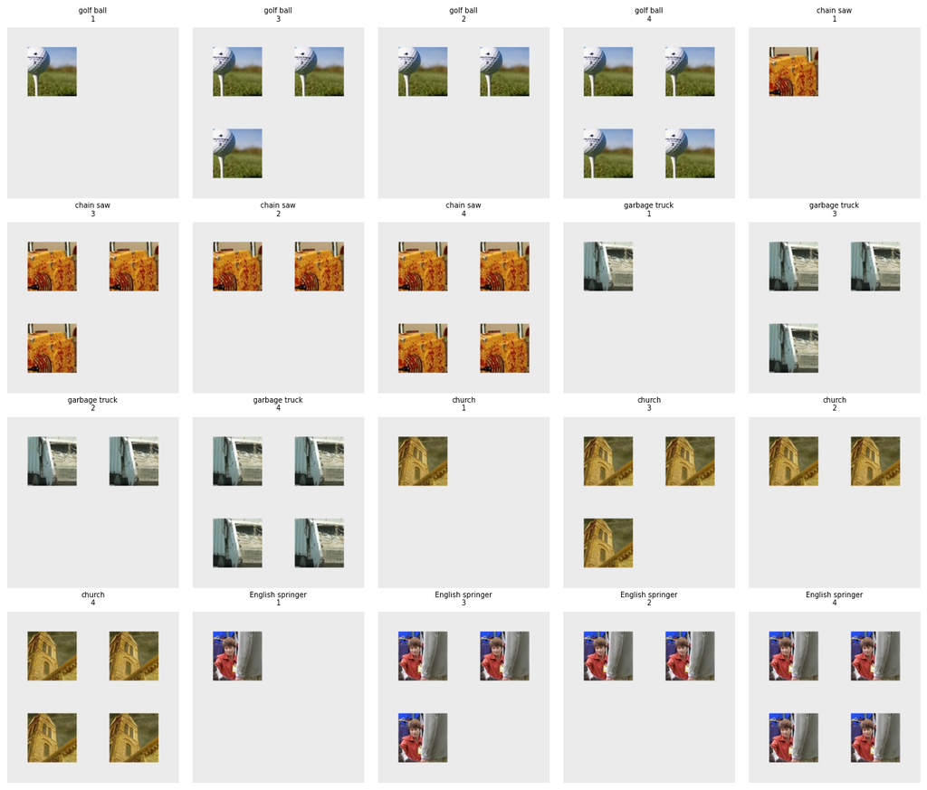

```
golf_ball_1v3                A:OK  B:OK  diag 0.2823/0.2975  off 0.2709/0.2969
golf_ball_2v4                A:OK  B:OK  diag 0.3034/0.3102  off 0.3002/0.2888
chain_saw_1v3                A:X   B:OK  diag 0.1815/0.2125  off 0.2011/0.1940
chain_saw_2v4                A:X   B:OK  diag 0.2116/0.2253  off 0.2223/0.1997
garbage_truck_1v3            A:X   B:OK  diag 0.2209/0.2465  off 0.2300/0.2383
garbage_truck_2v4            A:X   B:OK  diag 0.2492/0.2659  off 0.2622/0.2318
church_1v3                   A:X   B:OK  diag 0.2314/0.2428  off 0.2324/0.2398
church_2v4                   A:X   B:OK  diag 0.2486/0.2493  off 0.2572/0.2160
English_springer_1v3         A:X   B:OK  diag 0.1178/0.1277  off 0.1401/0.1113
English_springer_2v4         A:X   B:OK  diag 0.1330/0.1351  off 0.1390/0.1266

image-to-description accuracy: 0.600 (12/20)
sets with both images correct: 2/10 (chance ≈ 2.5)
```

```
mean similarity between the two descriptions in a set: 0.8656
mean similarity across all description pairs:          0.6688
```

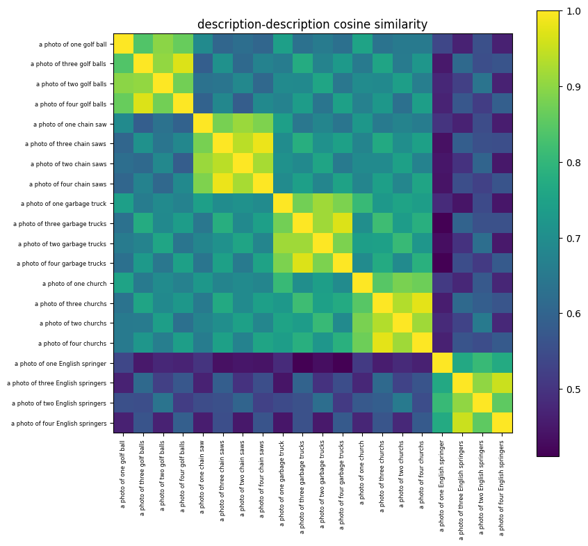

```
number words (original)            acc 0.600   A-correct 2/10   B-correct 10/10   both 2/10
digits                             acc 0.550   A-correct 3/10   B-correct 8/10   both 1/10
```

```
number words                       both-correct after per-caption centering: 7/10
digits                             both-correct after per-caption centering: 7/10
```

# Project 1, Part 3: A Controlled Study of CLIP's Limitations

## Task 1: Hypothesis and construction

**Hypothesis.** CLIP's image embeddings do not reliably support object counting. Given two descriptions naming the same object and differing only in number, image-to-description matching will perform near chance.

### Construction

Ten matched comparison sets, 20 images total. Each set contains two synthetic images and two descriptions differing only in the number word.

Images were composited programmatically: a center crop of one object was taken from a Part 1 image and pasted 1, 2, 3, or 4 times at fixed positions on a uniform light-grey canvas. Five object categories were used (golf ball, chain saw, garbage truck, church, English springer), each at two count contrasts (1 vs 3, and 2 vs 4).

**Why synthetic.** Constructing the images rather than collecting them controls every variable except count exactly: the two images in a set share identical object appearance, identical background, identical lighting, identical object size, and identical paste positions for the overlapping instances. Natural photographs differing in count would also differ in framing, scale, occlusion, and context, any of which could drive the result.

**Correct matches.** Image A pairs with the lower-count description, image B with the higher-count description. Chance accuracy is 50% per image; chance for getting both images in a set correct is 25%, or 2.5 sets out of 10.

**Confounding factors.**

- The images are synthetic composites, not natural photographs, and lie outside CLIP's training distribution. Results may not transfer to natural images.
- Higher-count images contain more total object pixels, so count is confounded with the fraction of the canvas occupied by the object.
- Count and object size could in principle be disentangled by scaling objects to hold total object area constant; this was not done.
- Only five object categories are used, and both contrasts within a category reuse the same source crop, so the ten sets are not fully independent.

## Task 2: Evaluation

### Image-to-description accuracy

**12/20 = 0.600.** Sets with both images matched correctly: **2/10**, against a chance expectation of 2.5/10.

The aggregate accuracy is misleading on its own. The per-image breakdown is:

|  | Correct |
| --- | --- |
| Image A (lower count) | 2/10 |
| Image B (higher count) | 10/10 |

The model chose the higher-count description for nearly every image regardless of what the image contained. A trivial strategy of always selecting the higher-count caption would score 10/20 = 0.500 and 0/10 on both-correct. The observed 0.600 reflects a caption preference, not counting ability.

Per-set results, showing the diagonal (correct) and off-diagonal (incorrect) similarities:

| Set | A | B | diag A/B | off A/B |
| --- | --- | --- | --- | --- |
| golf_ball 1v3 | OK | OK | 0.2823 / 0.2975 | 0.2709 / 0.2969 |
| golf_ball 2v4 | OK | OK | 0.3034 / 0.3102 | 0.3002 / 0.2888 |
| chain_saw 1v3 | X | OK | 0.1815 / 0.2125 | 0.2011 / 0.1940 |
| chain_saw 2v4 | X | OK | 0.2116 / 0.2253 | 0.2223 / 0.1997 |
| garbage_truck 1v3 | X | OK | 0.2209 / 0.2465 | 0.2300 / 0.2383 |
| garbage_truck 2v4 | X | OK | 0.2492 / 0.2659 | 0.2622 / 0.2318 |
| church 1v3 | X | OK | 0.2314 / 0.2428 | 0.2324 / 0.2398 |
| church 2v4 | X | OK | 0.2486 / 0.2493 | 0.2572 / 0.2160 |
| English_springer 1v3 | X | OK | 0.1178 / 0.1277 | 0.1401 / 0.1113 |
| English_springer 2v4 | X | OK | 0.1330 / 0.1351 | 0.1390 / 0.1266 |

The margins are very small throughout. In the failing A cases the incorrect similarity typically exceeds the correct one by 0.01–0.02, on values around 0.20–0.25.

### Successful cases

Both golf ball sets matched correctly on both images. Golf balls were also the tightest cluster in Part 2 Task 3 (within-category similarity 0.808), and the pasted spheres remain clearly separable against the plain canvas.

### Description-description similarity

- Mean similarity between the two descriptions within a set: **0.8656**
- Mean similarity across all description pairs: **0.6688**

Two captions naming the same object and differing only in the number word sit at 0.87 cosine similarity. The number word moves the text embedding very little; the object name dominates. The within-set figure being well above the overall mean confirms that the text encoder groups descriptions primarily by the object mentioned, not by the quantity.

This matters for the matching task. If the two candidate texts are nearly identical in embedding space, the image must produce an extremely precise similarity difference to separate them — and the observed margins of 0.01–0.02 show it does not reliably do so.

## Task 3: Testing one explanation

### Controlled change: digits instead of number words

One change was made — `one`/`two`/`three`/`four` replaced with `1`/`2`/`3`/`4`. All images, object categories, count contrasts, and the rest of the prompt text were held fixed.

| Variant | Accuracy | A correct | B correct | Both correct |
| --- | --- | --- | --- | --- |
| number words | 0.600 | 2/10 | 10/10 | 2/10 |
| digits | 0.550 | 3/10 | 8/10 | 1/10 |

The change **did not help**. Accuracy fell slightly and both-correct fell from 2/10 to 1/10. Both figures remain at or below the 2.5/10 chance baseline. The A/B asymmetry persists in the digit variant, though less extremely.

With ten sets, a difference of one set is well inside sampling noise, so the correct reading is that the numeral format has no meaningful effect — not that digits are worse.

### A second control: removing the caption-level offset

The A/B asymmetry suggests the failure may not be an inability to encode count at all, but a constant offset favouring one caption over the other across both images. To test this, each caption's similarity scores were centered by subtracting that caption's mean across the two images in its set, and the matching decision was re-made from the centered values.

| Variant | Both correct (raw) | Both correct (centered) |
| --- | --- | --- |
| number words | 2/10 | **7/10** |
| digits | 1/10 | **7/10** |

Both variants rise from at-or-below chance to 7/10. This changes the interpretation substantially: the relative ordering of similarities *does* track count, but it is masked by a caption-level bias large enough to dominate the raw argmax.

**This is a diagnostic, not a fix.** Centering requires both images in the set to compute the per-caption mean, so it is not a procedure CLIP could apply when scoring a single image against candidate texts. It establishes that count-relevant signal is present in the embeddings; it does not make CLIP a usable counter.

### Alternative explanations

Several accounts are consistent with these results and are not distinguished by this experiment.

**Count is confounded with object area.** Higher-count images contain proportionally more object pixels. The signal recovered by centering may track total object coverage rather than discrete count. Holding total object area constant while varying count would separate these.

**Caption bias may be length or frequency driven.** Descriptions with higher numbers may simply score higher against most images for reasons unrelated to the image, such as token frequency in the training captions. Testing captions with counts the image never contains would help isolate this.

**Synthetic images are out of distribution.** Tiled composites on a flat canvas do not resemble CLIP's web-image training data. The low absolute similarities throughout — English springer sets scored around 0.12, versus roughly 0.30 for natural images in Part 2 — indicate the model finds these images unfamiliar. Results on natural counting images could differ.

**Small sample.** Ten sets from five source images gives limited statistical power. The 2/10 vs 1/10 raw difference and even the 7/10 centered result carry wide uncertainty.

### Conclusion

The original hypothesis — that CLIP cannot support object counting — is **partially supported but too coarse**.

As CLIP would actually be used, the answer is yes: raw image-to-description matching performs at or below chance on these matched sets (2/10 and 1/10 sets fully correct against a 2.5/10 baseline), and this is unaffected by numeral format.

But the failure is not simply an absence of count information. After removing a caption-level offset, 7/10 sets resolve correctly, indicating the embeddings do carry a signal that varies with count. The practical failure arises because that signal is small relative to a bias that shifts both images in the same direction, and because the two candidate captions are themselves 0.87 similar in text-embedding space, leaving little room for the image to discriminate between them.

The more precise statement is that CLIP's absolute image–text similarities are not calibrated for comparing minimally different captions, even when the underlying representation distinguishes the images.